# ISLR Chapter 8

Alex Bayers

11/19/2018

### Exercise 3

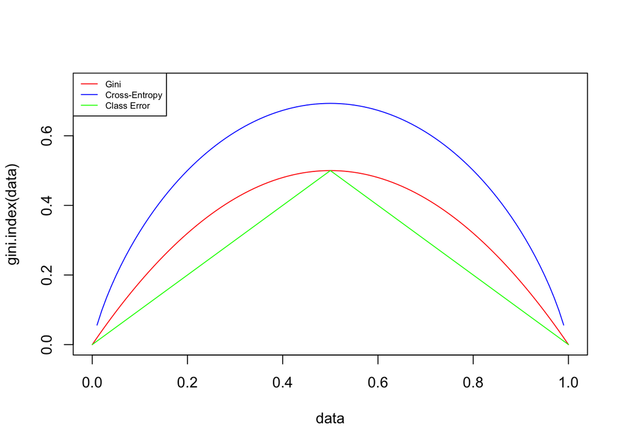

```r
data <- seq(from = 0, to = 1, by = .01)

gini.index <- function(probability){
  2*probability*(1-probability)
}

cross.entropy <- function(probability){
  -(probability)*log(probability) - (1-probability)*log(1 - probability)
}

classification.error <- function(probability){
  return(1 - max(probability, 1 - probability))
}

plot(x = data, y = gini.index(data), type = "l", col = "red", ylim = c(0, .75))
lines(x = data, y = cross.entropy(data), col = "blue")
lines(x = data, y = apply(as.matrix(data), 1, classification.error), col = "green")

legend("topleft", legend = c("Gini", "Cross-Entropy", "Class Error"), col = c("red", "blue", "green"), lty = 1, cex = 0.6)
```

### Exercise 5

```r
tree <- c(.1, .15, .2, .2, .55, .6, .6, .65, .7, .75)
mean(tree)
```

```
## [1] 0.45
```

```r
sum(tree >= .5)/length(tree)
```

```
## [1] 0.6
```

The average probility is .45, so the average probability rule classifies to green. By comparison, 60% of the trees classify to red, so the majority vote approach classifies to red.

### Exercise 6

We search along every axis, and find the optimal split within that axis. Then, we compare the best aplit amongst every axis, and choose the split that minimizes our objective criteria. We then loop through every area, and do the splits accordingly. Whichever one minimizes the value is the split we use.

### Exercise 7

```r
library(randomForest)
```

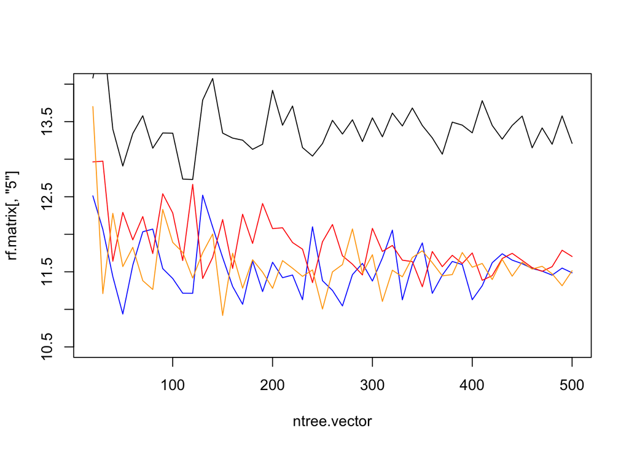

```r
library(MASS)
set.seed(1)
train = sample(1:nrow(Boston), nrow(Boston)/2)
boston.test=Boston[-train ,"medv"]
mtry.vector <- c(4, 5, 7, 13)
ntree.vector <- seq(20, 500, 10)
rf.matrix <- matrix(NA, nrow = length(ntree.vector), ncol = length(mtry.vector), dimnames = list(ntree.vector, mtry.vector))
for (i in ntree.vector){
  for (j in mtry.vector){
    rf.boston <- randomForest(medv ~., data = Boston, mtry = j, ntree = i, subset = train)
    yhat.rf <- predict(rf.boston ,newdata=Boston[-train ,])
    mse.rf <- mean((yhat.rf-boston.test)^2)
    rf.matrix[as.character(i), as.character(j)] <- mse.rf
  }
}

plot(x = ntree.vector, y = rf.matrix[,"5"], type = "l", col = "blue", ylim = c(10.5, 14))
lines(x = ntree.vector, y = rf.matrix[,"4"], type = "l", col = "red")
lines(x = ntree.vector, y = rf.matrix[,"7"], type = "l", col = "orange")
lines(x = ntree.vector, y = rf.matrix[,"13"], type = "l", col = "black")
```

A middling number entries in the mtry work better in the test set, with values performing best in 5 or 7 values. We see that prediction errors are nearly minized with 5 predictors entering and 50 trees, or 7 predictors entering and 150 trees. Interestingly, the prediction errors don’t seem to be very smooth - there is quite a bit of jaggedness in the prediction errors. Further, random forests seem to outperform bagging.

### Exercise 8

##### A

```r
library(ISLR)
library(tree)
library(randomForest)
set.seed(2)
train = sample(1:nrow(Carseats), nrow(Carseats)/2)
```

##### B

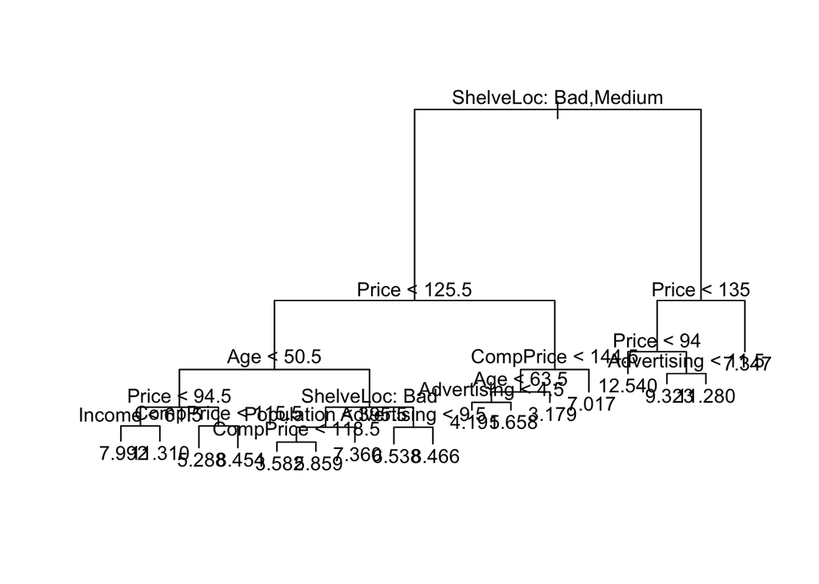

```r
tree.carseats <- tree(Sales ~., data = Carseats, subset = train)
par(mfrow = c(1,1))
plot(tree.carseats)
text(tree.carseats, pretty = 0)
```

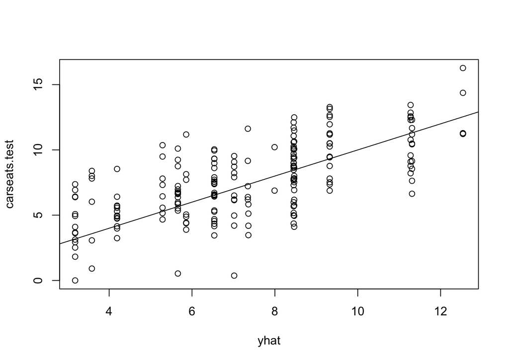

```r
#Prediction and diagnostics
yhat <- predict(tree.carseats, newdata = Carseats[-train,])
carseats.test=Carseats[-train ,"Sales"]
plot(yhat, carseats.test)
abline(0,1)
```

```r
mean((yhat-carseats.test)^2)
```

```
## [1] 4.844991
```

##### C

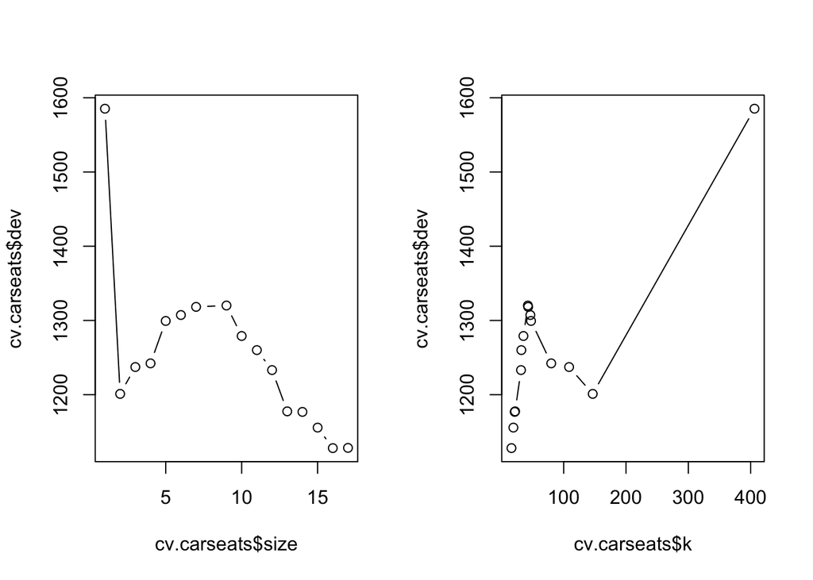

```r
#Now we go back and prune the trees
cv.carseats <- cv.tree(tree.carseats)
par(mfrow = c(1,2))
plot(cv.carseats$size ,cv.carseats$dev ,type="b")
plot(cv.carseats$k ,cv.carseats$dev ,type="b")
```

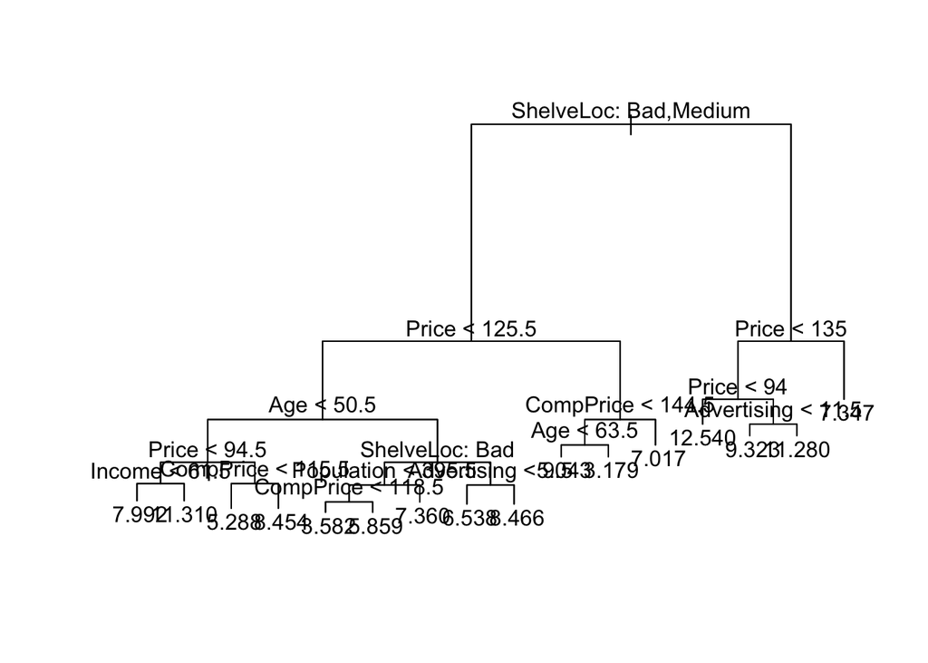

```r
#Fit pruned tree
par(mfrow = c(1,1))
prune.carseats=prune.tree(tree.carseats,best=16)
plot(prune.carseats)
text(prune.carseats, pretty = 0)
```

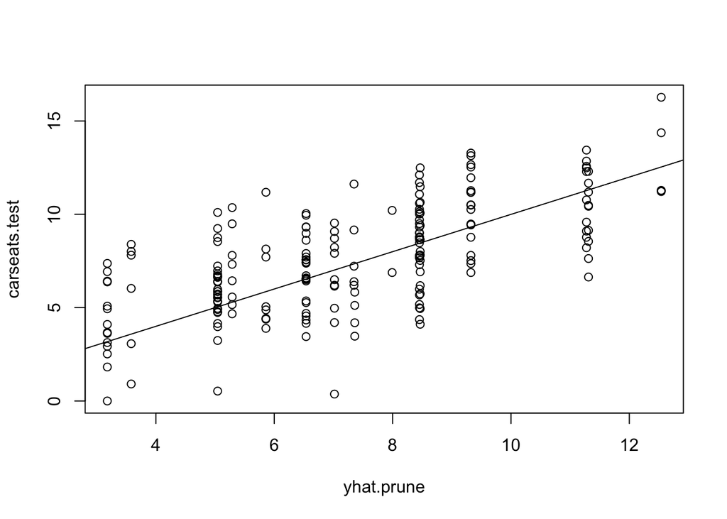

```r
#Prediction and diagnostics
yhat.prune <- predict(prune.carseats, newdata = Carseats[-train,])
plot(yhat.prune, carseats.test)
abline(0,1)
```

```r
mean((yhat.prune-carseats.test)^2)
```

```
## [1] 4.893985
```

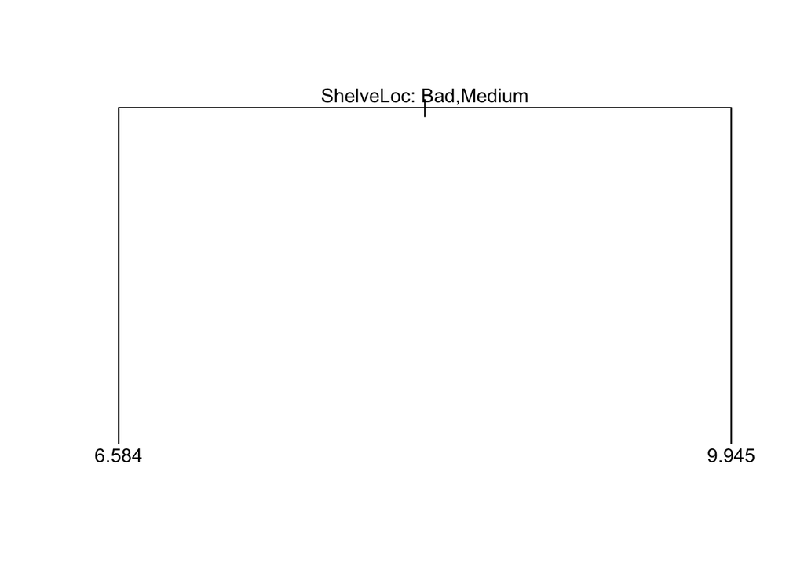

```r
#Fit pruned tree
par(mfrow = c(1,1))
small.carseats=prune.tree(tree.carseats,best=2)
plot(small.carseats)
text(small.carseats, pretty = 0)
```

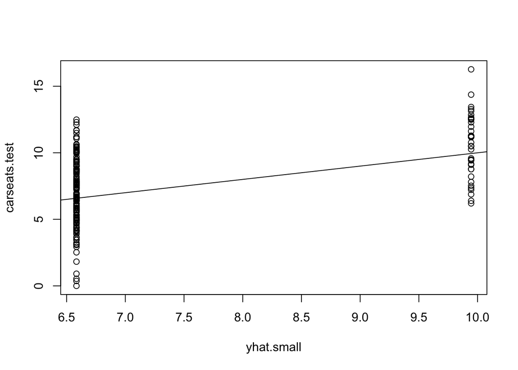

```r
#Prediction and diagnostics
yhat.small <- predict(small.carseats, newdata = Carseats[-train,])
plot(yhat.small, carseats.test)
abline(0,1)
```

```r
mean((yhat.small-carseats.test)^2)
```

```
## [1] 6.181133
```

```r
var(carseats.test)
```

```
## [1] 8.065432
```

The model seems to be minimized with size 16, which we go back and refit. The model fit seems worse, however. On the training set there is also a dip at 2, which we proceed to refit. The 16 point fit is much better than the 2 point fit on the test set, however, so we proceed to use the full model.

```r
bag.carseats=randomForest(Sales~.,data=Carseats,subset=train,mtry=10,importance =TRUE)
print(importance(bag.carseats))
```

```
##                %IncMSE IncNodePurity
## CompPrice   26.8209582    166.979714
## Income       2.5178689     70.424671
## Advertising 12.7943382     95.674806
## Population   1.5809962     66.767407
## Price       57.3318051    477.292357
## ShelveLoc   50.8691964    475.187526
## Age         12.9786136    126.420511
## Education   -1.8091675     37.001724
## Urban       -3.5410771      5.936702
## US          -0.8447167      6.800383
```

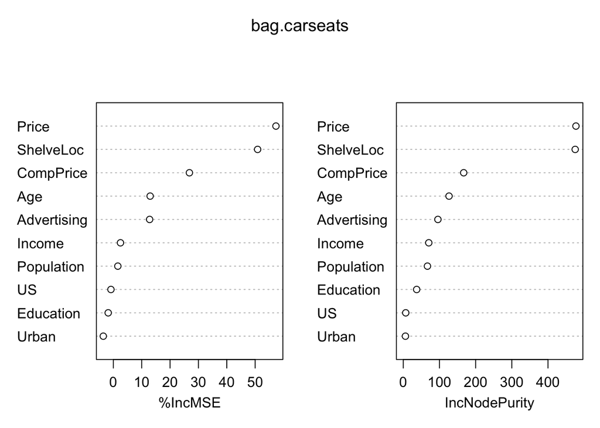

```r
varImpPlot(bag.carseats)
```

```r
yhat.bag <- predict(bag.carseats ,newdata=Carseats[-train ,])
mean((yhat.bag-carseats.test)^2)
```

```
## [1] 2.369187
```

The test error is 2.4, which is much better than the predictions from the tree predictor. I think this is because it places a much greater emphasis on price, ranking it alongside shelve location, and presumably the effect of price is closer to linear.

```r
rf.carseats=randomForest(Sales~.,data=Carseats,subset=train,mtry=3,importance =TRUE)
print(importance(rf.carseats))
```

```
##                %IncMSE IncNodePurity
## CompPrice   13.9082873     143.70588
## Income      -1.1881180      95.40114
## Advertising  8.1765225     116.01780
## Population  -1.4440692     112.32290
## Price       37.5120708     386.90793
## ShelveLoc   39.9627269     350.46676
## Age         11.8981617     158.21652
## Education   -0.5830359      67.83125
## Urban       -0.7235525      14.13967
## US           0.5890730      16.34130
```

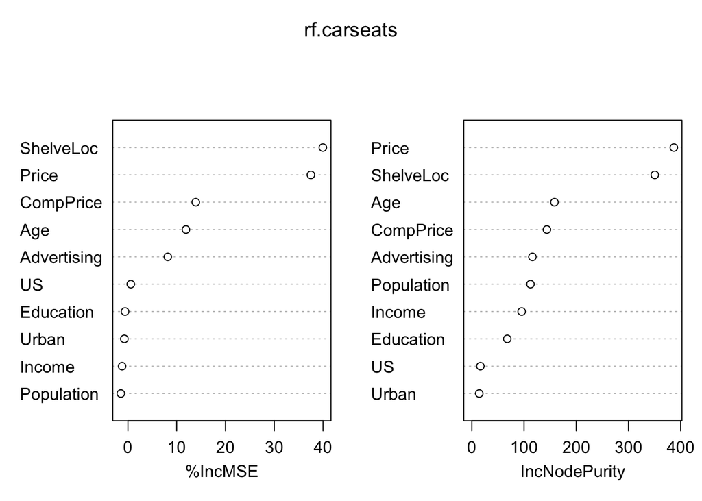

```r
varImpPlot(rf.carseats)
```

```r
yhat.rf <- predict(rf.carseats ,newdata=Carseats[-train ,])
mean((yhat.rf-carseats.test)^2)
```

```
## [1] 2.961581
```

```r
rf.carseats.new=randomForest(Sales~.,data=Carseats,subset=train,mtry=5,importance =TRUE)
print(importance(rf.carseats.new))
```

```
##                %IncMSE IncNodePurity
## CompPrice   18.4306973     158.25790
## Income      -0.7934852      84.45019
## Advertising 11.1947366     103.60986
## Population   1.2054504      87.28626
## Price       45.0470645     444.72167
## ShelveLoc   43.8815726     403.09518
## Age         12.0507717     153.69775
## Education   -1.4194686      49.13270
## Urban       -1.2989493       8.78178
## US           2.4428184      12.61672
```

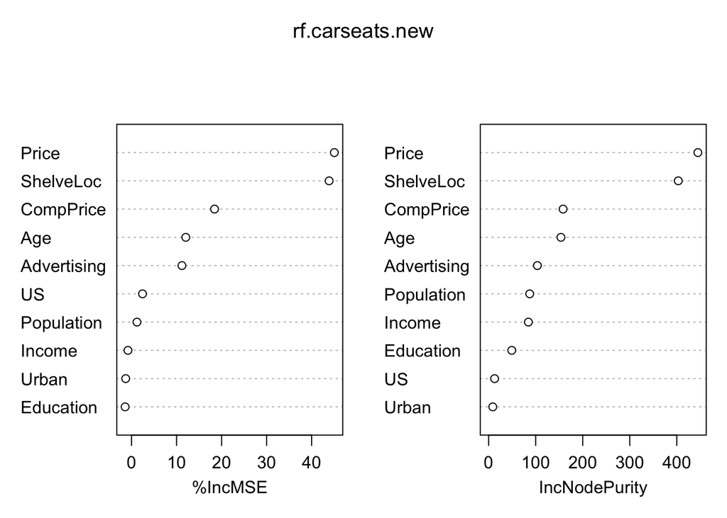

```r
varImpPlot(rf.carseats.new)
```

```r
yhat.rf.new <- predict(rf.carseats.new ,newdata=Carseats[-train ,])
mean((yhat.rf.new-carseats.test)^2)
```

```
## [1] 2.610513
```

The relative weighting of the price and shelving go up as we add in more potential predictors. The test accuracy seems to increase with the number of predictors entering the tree, with going from 2.95 with p = 3, to 2.61 with p = 5, to 2.37 with p = 10 (bagging).

### Exercise 9

##### A

```r
train <- sample(1:dim(OJ)[1], 800, replace = FALSE)
```

##### B

```r
OJ.tree <- tree(Purchase ~., data = OJ, subset = train)
summary(OJ.tree)
```

```
##
## Classification tree:
## tree(formula = Purchase ~ ., data = OJ, subset = train)
## Variables actually used in tree construction:
## [1] "LoyalCH"     "PriceDiff"   "SalePriceMM"
## Number of terminal nodes:  8
## Residual mean deviance:  0.7362 = 583.1 / 792
## Misclassification error rate: 0.1538 = 123 / 800
```

##### C

```r
OJ.tree
```

```
## node), split, n, deviance, yval, (yprob)
##       * denotes terminal node
##
##  1) root 800 1067.00 CH ( 0.61375 0.38625 )
##    2) LoyalCH < 0.50395 344  401.50 MM ( 0.27035 0.72965 )
##      4) LoyalCH < 0.276142 163  121.40 MM ( 0.12270 0.87730 )
##        8) LoyalCH < 0.035047 56   10.03 MM ( 0.01786 0.98214 ) *
##        9) LoyalCH > 0.035047 107  100.10 MM ( 0.17757 0.82243 ) *
##      5) LoyalCH > 0.276142 181  244.10 MM ( 0.40331 0.59669 )
##       10) PriceDiff < 0.05 79   70.65 MM ( 0.16456 0.83544 ) *
##       11) PriceDiff > 0.05 102  138.20 CH ( 0.58824 0.41176 ) *
##    3) LoyalCH > 0.50395 456  347.50 CH ( 0.87281 0.12719 )
##      6) LoyalCH < 0.764572 189  209.80 CH ( 0.75661 0.24339 )
##       12) PriceDiff < -0.165 26   32.10 MM ( 0.30769 0.69231 ) *
##       13) PriceDiff > -0.165 163  149.50 CH ( 0.82822 0.17178 )
##         26) SalePriceMM < 2.125 95  109.50 CH ( 0.73684 0.26316 ) *
##         27) SalePriceMM > 2.125 68   24.59 CH ( 0.95588 0.04412 ) *
##      7) LoyalCH > 0.764572 267   97.91 CH ( 0.95506 0.04494 ) *
```

##### D

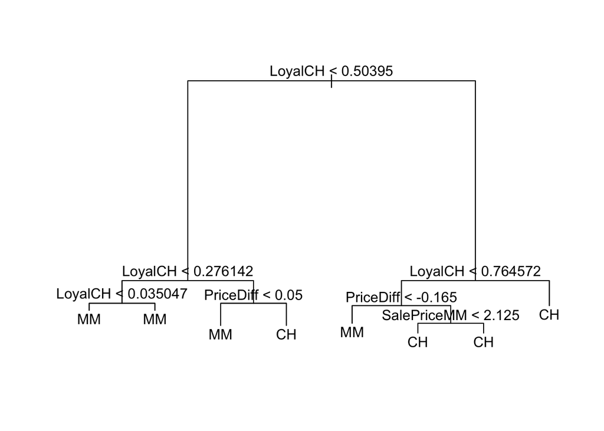

```r
plot(OJ.tree)
text(OJ.tree)
```

##### E

```r
tree.pred=predict(OJ.tree,OJ[-train,],type="class")
table(tree.pred ,OJ[-train,]$Purchase)
```

```
##
## tree.pred  CH  MM
##        CH 142  32
##        MM  20  76
```

```r
1 - (155+68)/sum(table(tree.pred ,OJ[-train,]$Purchase))
```

[output not shown]

##### F, G, & H

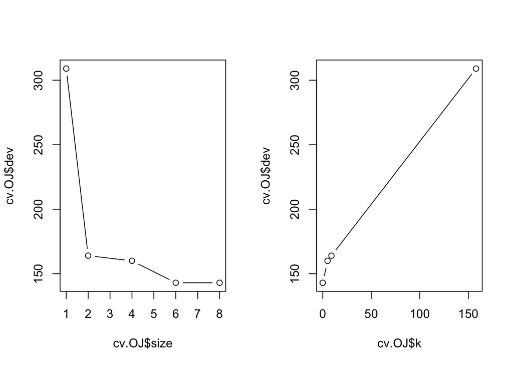

```r
cv.OJ <- cv.tree(OJ.tree, FUN = prune.misclass)
par(mfrow = c(1,2))
plot(cv.OJ$size ,cv.OJ$dev ,type="b")
plot(cv.OJ$k ,cv.OJ$dev ,type="b")
```

6 nodes looks to be the appropriate amount of pruning.

##### I

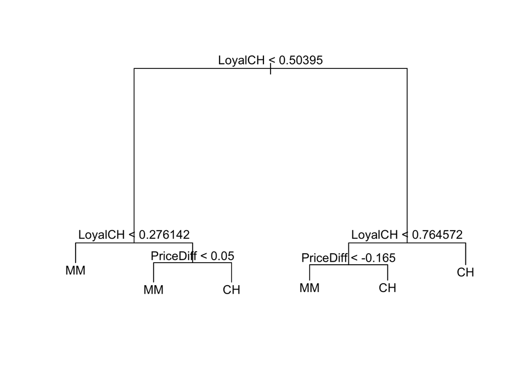

```r
prune.OJ <- prune.misclass(OJ.tree, best = 6)
plot(prune.OJ)
text(prune.OJ, pretty = 0)
```

##### J & K

```r
train.full <- predict(OJ.tree, type = "class")
#Return the training error rate for the full tree
1 - sum(train.full == OJ[train,]$Purchase)/800
```

```
## [1] 0.15375
```

```r
train.prune <- predict(prune.OJ, type = "class")
#Return the training error rate for the pruned tree
1 - sum(train.prune == OJ[train,]$Purchase)/800
```

```
## [1] 0.15375
```

```r
test.full <- predict(OJ.tree, newdata = OJ[-train,], type = "class")
#Return the test error rate for the full tree
1 - sum(test.full == OJ[-train,]$Purchase)/270
```

```
## [1] 0.1925926
```

```r
test.prune <- predict(prune.OJ, newdata = OJ[-train,], type = "class")
#Return the test error rate for the pruned tree
1 - sum(test.prune == OJ[-train,]$Purchase)/270
```

```
## [1] 0.1925926
```

Test and training errors are the same for both approaches.

### Exercise 10

##### A

```r
set.seed(10)
complete.hitters <- Hitters[complete.cases(Hitters),]
complete.hitters$LogSalary <- log(complete.hitters$Salary)
```

##### B

```r
train <- complete.hitters[1:200,]
test <- complete.hitters[201:263,]
```

##### C

```r
library(gbm)
```

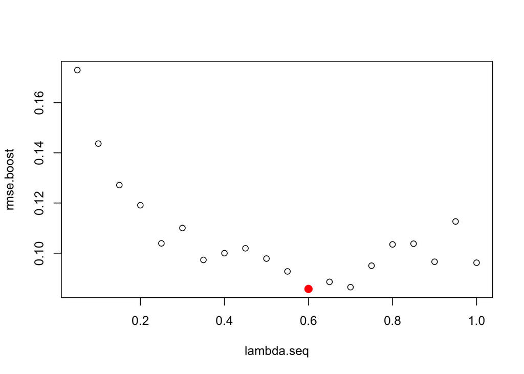

```r
set.seed(1)
hitter.gbm <- function(lambda){
  set.seed(13)
  gbm(LogSalary ~.-Salary, data = train, distribution = "gaussian", n.trees = 100, shrinkage = lambda)
}

lambda.seq <- seq(from = 0.05, to =1, by =0.05)
model.names <- paste("model_", lambda.seq, sep = '')
models <- lapply(lambda.seq, hitter.gbm)
names(models) <- model.names

rmse.boost <- vector(length=length(lambda.seq))
for (i in 1:length(rmse.boost)){
  rmse.boost[i] <- (sum((predict(models[[i]], newdata = train, n.trees = 100) - train$LogSalary)^2)/200)
}
plot(x = lambda.seq, y = rmse.boost)
points(x=lambda.seq[which.min(rmse.boost)], y = min(rmse.boost), col = 'red', cex = 2, pch = 20)
```

##### D

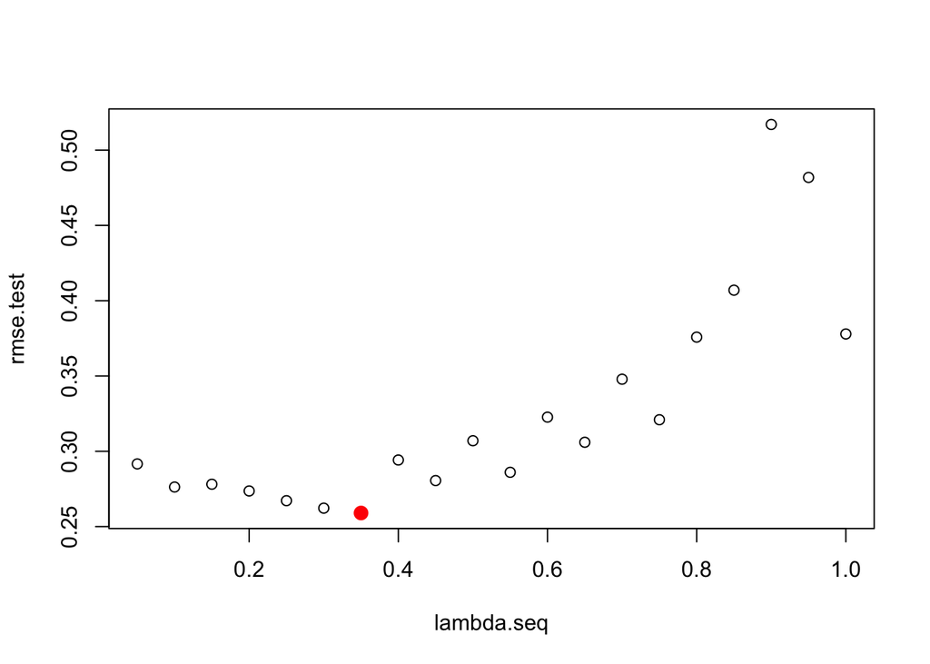

```r
rmse.test <- vector(length=length(lambda.seq))
for (i in 1:length(rmse.test)){
  rmse.test[i] <- (sum((predict(models[[i]], newdata = test, n.trees = 100) - test$LogSalary)^2)/63)
}
plot(x = lambda.seq, y = rmse.test)
points(x=lambda.seq[which.min(rmse.test)], y = min(rmse.test), col = 'red', cex = 2, pch = 20)
```

```r
print(min(rmse.test))
```

```
## [1] 0.2590311
```

##### E

We will compare our models to lasso and ridge regression.

```r
#Ridge regression model
library(glmnet)
```

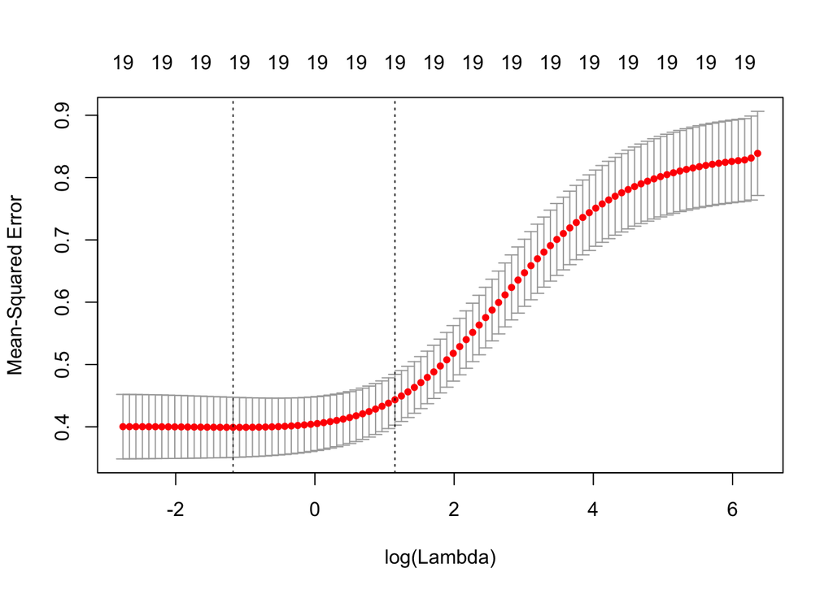

```r
set.seed (1)
my.grid=10^seq(10,-2,length=100)
x=model.matrix(LogSalary~.-Salary,train)[,-1]
y = train$LogSalary
cv.out=cv.glmnet(x,y,alpha=0)
plot(cv.out)
```

```r
bestlam=cv.out$lambda.min
ridge.mod=glmnet(x,y,alpha=0,lambda=my.grid, thresh =1e-12)
x.test <- model.matrix(LogSalary~.-Salary,test)[,-1]
y.test <- test$LogSalary
ridge.pred=predict(ridge.mod,s=bestlam,newx=x.test)
mean((ridge.pred-y.test)^2)
```

```
## [1] 0.4521959
```

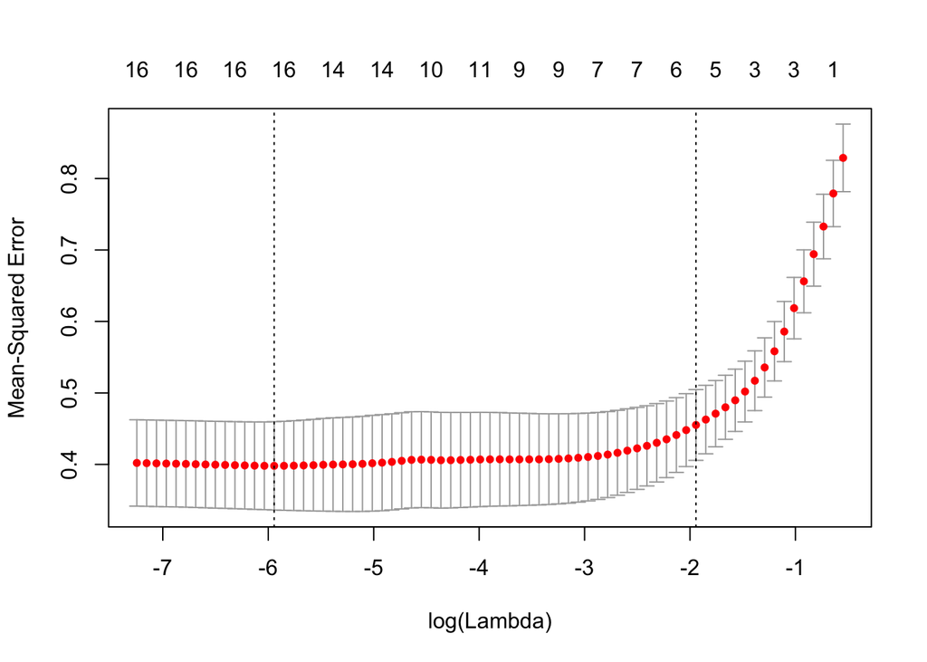

```r
cv.outnew=cv.glmnet(x,y,alpha=1)
plot(cv.outnew)
```

```r
bestlam.new=cv.outnew$lambda.min
lasso.mod=glmnet(x,y,alpha=1,lambda=my.grid, thresh =1e-12)
lasso.pred=predict(lasso.mod,s=bestlam,newx=x.test)
mean((lasso.pred-y.test)^2)
```

```
## [1] 0.476247
```

##### F

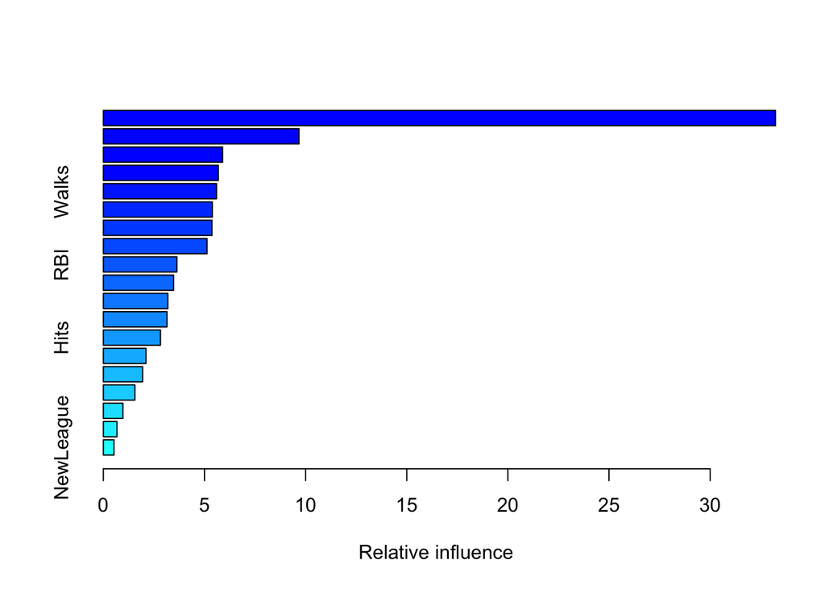

```
##                 var    rel.inf
## CAtBat       CAtBat 33.2310420
## AtBat         AtBat  9.6714294
## Assists     Assists  5.8939160
## PutOuts     PutOuts  5.6845523
## Walks         Walks  5.5945336
## CHmRun       CHmRun  5.3882504
## CWalks       CWalks  5.3700758
## CHits         CHits  5.1268584
## RBI             RBI  3.6366413
## HmRun         HmRun  3.4719784
## Years         Years  3.1884818
## Runs           Runs  3.1452777
## Hits           Hits  2.8238896
## CRuns         CRuns  2.1064916
## Division   Division  1.9426969
## Errors       Errors  1.5586852
## CRBI           CRBI  0.9680514
## League       League  0.6730122
## NewLeague NewLeague  0.5241361
```

```r
set.seed(13)
x <- gbm(LogSalary ~.-Salary, data = train, distribution = "gaussian", n.trees = 100, interaction.depth = 4, shrinkage = 0.65)
summary(x)
```

##### G

```r
library(randomForest)
bag.salary=randomForest(LogSalary~.-Salary,data=train, mtry=6, ntree=500)
yhat.bag = predict(bag.salary ,newdata=test)
mean((yhat.bag-test$LogSalary)^2)
```

```
## [1] 0.2173822
```

```r
library(randomForest)
bag.salary=randomForest(LogSalary~.-Salary,data=train, mtry=18, ntree=500)
yhat.bag = predict(bag.salary ,newdata=test)
mean((yhat.bag-test$LogSalary)^2)
```

```
## [1] 0.2233832
```

### Exercise 11

##### A

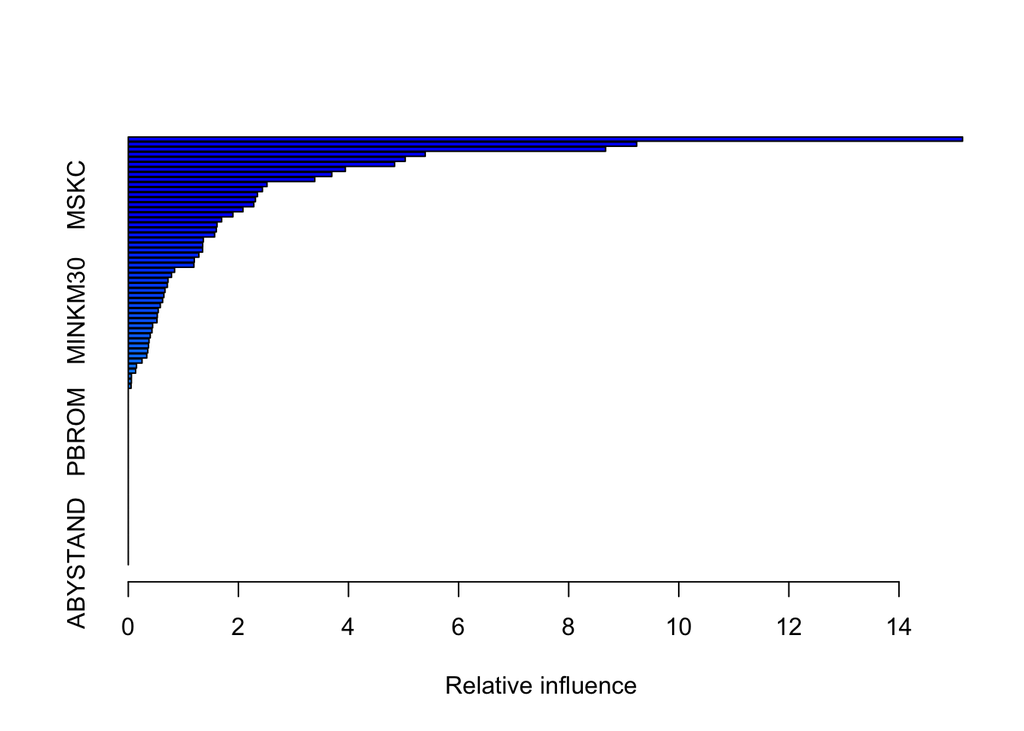

```
##               var     rel.inf
## PPERSAUT PPERSAUT 15.15534009
## MKOOPKLA MKOOPKLA  9.23499526
## MOPLHOOG MOPLHOOG  8.67017024
## MBERMIDD MBERMIDD  5.39403655
## MGODGE     MGODGE  5.03047673
## PBRAND     PBRAND  4.83740038
## MINK3045 MINK3045  3.94305387
## ABRAND     ABRAND  3.69692919
## MOSTYPE   MOSTYPE  3.38768960
## PWAPART   PWAPART  2.51970169
## MGODPR     MGODPR  2.43689096
## MSKC         MSKC  2.34594774
## MAUT2       MAUT2  2.30973409
## MFWEKIND MFWEKIND  2.27959503
## MBERARBG MBERARBG  2.08245286
## MSKA         MSKA  1.90020973
## PBYSTAND PBYSTAND  1.69481877
## MGODOV     MGODOV  1.61147668
## MAUT1       MAUT1  1.59879109
## MBERHOOG MBERHOOG  1.56791308
## MINK7512 MINK7512  1.36255296
## MSKB1       MSKB1  1.35071475
## MINKGEM   MINKGEM  1.34913011
## MRELGE     MRELGE  1.28204167
## MAUT0       MAUT0  1.19929798
## MHHUUR     MHHUUR  1.19158719
## MFGEKIND MFGEKIND  0.84203310
## MRELOV     MRELOV  0.78554535
## MZPART     MZPART  0.72191139
## MINK4575 MINK4575  0.70935967
## MSKB2       MSKB2  0.66694112
## APERSAUT APERSAUT  0.64644681
## MGODRK     MGODRK  0.62380797
## MSKD         MSKD  0.58168337
## MINKM30   MINKM30  0.54392696
## PMOTSCO   PMOTSCO  0.52708603
## MOPLMIDD MOPLMIDD  0.52091706
## MGEMOMV   MGEMOMV  0.44231264
## MZFONDS   MZFONDS  0.43037800
```

[output cut: 31 more lines]

```
## AMOTSCO   AMOTSCO  0.00000000
## AVRAAUT   AVRAAUT  0.00000000
## AAANHANG AAANHANG  0.00000000
## ATRACTOR ATRACTOR  0.00000000
## AWERKT     AWERKT  0.00000000
## ABROM       ABROM  0.00000000
## ALEVEN     ALEVEN  0.00000000
## APERSONG APERSONG  0.00000000
## AGEZONG   AGEZONG  0.00000000
## AWAOREG   AWAOREG  0.00000000
## AZEILPL   AZEILPL  0.00000000
## APLEZIER APLEZIER  0.00000000
## AFIETS     AFIETS  0.00000000
## AINBOED   AINBOED  0.00000000
## ABYSTAND ABYSTAND  0.00000000
```

```r
set.seed(342)
train <- 1:1000
Caravan$Purchase = ifelse(Caravan$Purchase == "Yes", 1, 0)
Caravan.train <- Caravan[train,]
Caravan.test <- Caravan[-train,]
gbm.caravan <- gbm(Purchase ~., data = Caravan.train, distribution = "bernoulli", shrinkage = .01, n.trees = 1000)
summary(gbm.caravan)
```

```r
Train.purchase <- ifelse(predict(gbm.caravan, newdata = Caravan.train, n.trees = 1000, type = "response") > .2, 1, 0)
table(Caravan.train$Purchase, Train.purchase)
```

```
##    Train.purchase
##       0   1
##   0 925  16
##   1  42  17
```

```r
Test.purchase <- ifelse(predict(gbm.caravan, newdata = Caravan.test, n.trees = 1000, type = "response") > .2, 1, 0)
table(Caravan.test$Purchase, Test.purchase)
```

```
##    Test.purchase
##        0    1
##   0 4396  137
##   1  255   34
```

```r
34/(34+137)
```

```
## [1] 0.1988304
```

```r
glm.model <- glm(Purchase ~ ., data = Caravan.train)
reduced.glm.model <- glm(Purchase ~ PPERSAUT + PWAOREG + AWAOREG, data = Caravan.train)
Test.glm.purchase <- ifelse(predict(reduced.glm.model, newdata = Caravan.test, type = "response") > .2, 1, 0)
table(Caravan.test$Purchase, Test.glm.purchase)
```

```
##    Test.glm.purchase
##        0    1
##   0 4519   14
##   1  287    2
```

About 19.9% of those predicted to make a purchase make one.